# Imorting Libraries

```python
import os
import re
import cv2
import torch
import numpy as np
import pandas as pd
import matplotlib.pyplot as plt
import matplotlib
import seaborn as sns
import plotly.express as px
import plotly.graph_objects as go
from torchvision import models, transforms
from torch.nn import functional as F
from sklearn.model_selection import train_test_split
from sklearn.impute import SimpleImputer
from sklearn.preprocessing import StandardScaler, OneHotEncoder, OrdinalEncoder, LabelEncoder
from sklearn.compose import ColumnTransformer
from sklearn.pipeline import Pipeline
from sklearn.ensemble import RandomForestClassifier
from sklearn.linear_model import LogisticRegression
from sklearn.metrics import classification_report, confusion_matrix, accuracy_score
from sklearn.tree import plot_tree
import pickle
import matplotlib.pyplot as plt
from sklearn.tree import plot_tree
```

## Adding paths

```python
while True:
    c = input('Enter your name: ').lower()
    if c =='hassan':
        tabular_data_path = 'D:/Masters/Semester2/Data mining/Project/DataMining/Dataset/app_data.xlsx'
        image_dir = 'D:/Masters/Semester2/Data mining/Project/DataMining/Dataset/Images'
        to_save = 'D:/Masters/Semester2/Data mining/Project/DataMining/Dataset/merged_data_with_image_features.csv'
        break
    elif c =='muneeb':
        tabular_data_path = 'C:/Users/Syed Muhammad Muneeb/Downloads/DataMiningDS/app_data.xlsx'
        image_dir = 'C:/Users/Syed Muhammad Muneeb/Downloads/DataMiningDS'
        to_save = 'C:/Users/Syed Muhammad Muneeb/Downloads/DataMiningDS/merged_data_with_image_features.csv'
        break
    elif c == 'sameer':
        tabular_data_path = 'E:/Masters Data Science/2nd Sem/Data mining/Project/Project dataset/app_data.xlsx'
        image_dir = 'E:/Masters Data Science/2nd Sem/Data mining/Project/Project dataset/US_Pictures/US_Pictures/'
        to_save = 'E:/Masters Data Science/2nd Sem/Data mining/Project/Project dataset/merged_data_with_image_features.csv'
        break
    else:
        print('Ops! You made a boo boo please check your name again')
        continue
```

```python
print(tabular_data_path)
```

```
D:/Masters/Semester2/Data mining/Project/DataMining/Dataset/app_data.xlsx
```

The implemented approach generates a comprehensive summary of the dataset to facilitate initial data exploration and preprocessing. We created a dictionary, summary, that includes key dataset details such as shape (number of rows and columns), column data types, missing values, and sample data. We then categorized columns into numerical and categorical types using the select_dtypes() function, followed by computing descriptive statistics for each type. Numerical columns were summarized with metrics like mean and standard deviation, while categorical columns were analyzed for unique values and frequencies. Finally, the summary dictionary was updated with the extracted insights, providing a structured overview of the dataset. This approach helped in identifying data quality issues, understanding variable distributions, and preparing the data for further processing and analysis.

```python
# Summary of the dataset
summary = {
    "Shape": df.shape,
    "Info": df.info(),
    "Missing Values": df.isnull().sum(),
    "Sample Data": df.head(),
}

# Separate numerical and categorical columns
numerical_columns = df.select_dtypes(include=['number']).columns
categorical_columns = df.select_dtypes(include=['object', 'category']).columns

# Summary of numerical and categorical columns
numerical_summary = df[numerical_columns].describe()
categorical_summary = df[categorical_columns].describe()

summary.update({
    "Numerical Columns": numerical_columns.tolist(),
    "Categorical Columns": categorical_columns.tolist(),
    "Numerical Summary": numerical_summary,
    "Categorical Summary": categorical_summary,
})

summary
```

```
<class 'pandas.core.frame.DataFrame'>
RangeIndex: 782 entries, 0 to 781
Data columns (total 58 columns):
 #   Column                            Non-Null Count  Dtype
---  ------                            --------------  -----
 0   Age                               781 non-null    float64
 1   BMI                               755 non-null    float64
 2   Sex                               780 non-null    object
 3   Height                            756 non-null    float64
 4   Weight                            779 non-null    float64
 5   Length_of_Stay                    778 non-null    float64
 6   Management                        781 non-null    object
 7   Severity                          781 non-null    object
 8   Diagnosis_Presumptive             780 non-null    object
 9   Diagnosis                         780 non-null    object
```

[output cut: 50 more lines]

```
{'Shape': (782, 58),
 'Info': None,
 'Missing Values': Age                                   1
 BMI                                  27
 Sex                                   2
 Height                               26
 Weight                                3
 Length_of_Stay                        4
 Management                            1
 Severity                              1
 Diagnosis_Presumptive                 2
 Diagnosis                             2
 Alvarado_Score                       52
 Paedriatic_Appendicitis_Score        52
 Appendix_on_US                        5
 Appendix_Diameter                   284
 Migratory_Pain                        9
 Lower_Right_Abd_Pain                  8
 Contralateral_Rebound_Tenderness     15
 Coughing_Pain                        16
 Nausea                                8
 Loss_of_Appetite                     10
 Body_Temperature                      7
 WBC_Count                             6
 Neutrophil_Percentage               103
 Segmented_Neutrophils               728
 Neutrophilia                         50
 RBC_Count                            18
 Hemoglobin                           18
 RDW                                  26
 Thrombocyte_Count                    18
 Ketones_in_Urine                    200
 RBC_in_Urine                        206
 WBC_in_Urine                        199
 CRP                                  11
 Dysuria                              29
 Stool                                17
 Peritonitis                           9
 Psoas_Sign                           37
 Ipsilateral_Rebound_Tenderness      163
```

[output cut: 186 more lines]

```
 freq                        154                   37                    55

        Conglomerate_of_Bowel_Loops Ileus Coprostasis Meteorism Enteritis  \
 count                           43    60          71       140        66
 unique                           2     2           2         2         2
 top                             no    no         yes       yes       yes
 freq                            22    37          46       129        51

        Gynecological_Findings
 count                      26
 unique                     14
 top                     keine
 freq                        9

 [4 rows x 40 columns]}
```

The implemented approach calculates the total and percentage of missing values in the dataset to facilitate data quality assessment. We computed the total null values for each column using the isnull().sum() function and cal-culated the corresponding percentage by dividing the total null values by the dataset length and multiplying by 100. A summary table was then created using the Pandas DataFrame function, containing columns for the total num-ber of null values and their corresponding percentages. The table was sorted in descending order based on the total null values to prioritize columns with the highest missing data, and the index was reset for better readabil-ity. This approach helps in identifying missing data patterns, assessing data completeness, and making informed de-cisions regarding data imputation or removal strategies.

```python
# Calculate the total and percentage of null values in the dfset
null_values = df.isnull().sum()
null_percentage = (null_values / len(df)) * 100

# Create a summary table for columns with null values
null_summary = pd.DataFrame({
    "Column": df.columns,
    "Total_Null_Values": null_values,
    "Percentage_Null_Values": null_percentage
}).sort_values(by="Total_Null_Values", ascending=False).reset_index(drop=True)

null_summary
```

|  | Column | Total_Null_Values | Percentage_Null_Values |
| --- | --- | --- | --- |
| 0 | Abscess_Location | 769 | 98.337596 |
| 1 | Gynecological_Findings | 756 | 96.675192 |
| 2 | Conglomerate_of_Bowel_Loops | 739 | 94.501279 |
| 3 | Segmented_Neutrophils | 728 | 93.094629 |
| 4 | Ileus | 722 | 92.327366 |
| 5 | Perfusion | 719 | 91.943734 |
| 6 | Enteritis | 716 | 91.560102 |
| 7 | Appendicolith | 713 | 91.176471 |
| 8 | Coprostasis | 711 | 90.920716 |
| 9 | Perforation | 701 | 89.641944 |
| 10 | Appendicular_Abscess | 697 | 89.130435 |
| 11 | Bowel_Wall_Thickening | 683 | 87.340153 |
| 12 | Lymph_Nodes_Location | 661 | 84.526854 |
| 13 | Target_Sign | 644 | 82.352941 |
| 14 | Meteorism | 642 | 82.097187 |
| 15 | Pathological_Lymph_Nodes | 579 | 74.040921 |
| 16 | Appendix_Wall_Layers | 564 | 72.122762 |
| 17 | Surrounding_Tissue_Reaction | 530 | 67.774936 |
| 18 | Appendix_Diameter | 284 | 36.317136 |
| 19 | RBC_in_Urine | 206 | 26.342711 |
| 20 | Ketones_in_Urine | 200 | 25.575448 |
| 21 | WBC_in_Urine | 199 | 25.447570 |
| 22 | Ipsilateral_Rebound_Tenderness | 163 | 20.843990 |
| 23 | Neutrophil_Percentage | 103 | 13.171355 |
| 24 | Free_Fluids | 63 | 8.056266 |
| 25 | Alvarado_Score | 52 | 6.649616 |
| 26 | Paedriatic_Appendicitis_Score | 52 | 6.649616 |
| 27 | Neutrophilia | 50 | 6.393862 |
| 28 | Psoas_Sign | 37 | 4.731458 |
| 29 | Dysuria | 29 | 3.708440 |
| 30 | BMI | 27 | 3.452685 |
| 31 | Height | 26 | 3.324808 |
| 32 | RDW | 26 | 3.324808 |
| 33 | US_Number | 22 | 2.813299 |
| 34 | Thrombocyte_Count | 18 | 2.301790 |
| 35 | Hemoglobin | 18 | 2.301790 |
| 36 | RBC_Count | 18 | 2.301790 |
| 37 | Stool | 17 | 2.173913 |
| 38 | Coughing_Pain | 16 | 2.046036 |
| 39 | Contralateral_Rebound_Tenderness | 15 | 1.918159 |
| 40 | CRP | 11 | 1.406650 |
| 41 | Loss_of_Appetite | 10 | 1.278772 |
| 42 | Peritonitis | 9 | 1.150895 |
| 43 | Migratory_Pain | 9 | 1.150895 |
| 44 | Nausea | 8 | 1.023018 |
| 45 | Lower_Right_Abd_Pain | 8 | 1.023018 |
| 46 | Body_Temperature | 7 | 0.895141 |
| 47 | WBC_Count | 6 | 0.767263 |
| 48 | Appendix_on_US | 5 | 0.639386 |
| 49 | Length_of_Stay | 4 | 0.511509 |
| 50 | US_Performed | 4 | 0.511509 |
| 51 | Weight | 3 | 0.383632 |
| 52 | Diagnosis | 2 | 0.255754 |
| 53 | Diagnosis_Presumptive | 2 | 0.255754 |
| 54 | Sex | 2 | 0.255754 |
| 55 | Severity | 1 | 0.127877 |
| 56 | Management | 1 | 0.127877 |
| 57 | Age | 1 | 0.127877 |

The implemented approach focuses on handling missing data by removing columns with excessive null values. We first calculated a threshold, set at 50% of the total number of rows in the dataset, using len(df) * 0.5. This threshold serves as a benchmark to identify columns with a high proportion of missing values. Columns where the number of null values exceeds this threshold were dropped using the df.loc[:, df.isnull().sum() <= threshold] statement, ensuring only columns with an acceptable level of missing data are retained.

```python
# Calculate the threshold for 60% null values
threshold = len(df) * 0.5

# Drop columns where the number of null values exceeds the threshold
df_cleaned = df.loc[:, df.isnull().sum() <= threshold]

# Display the shape of the cleaned dataframe
print("Original shape:", df.shape)
print("Cleaned shape:", df_cleaned.shape)
```

```
Original shape: (782, 58)
Cleaned shape: (782, 40)
```

```python
numerical_columns = df_cleaned.select_dtypes(include=["number"]).columns
print("Numerical Columns:")
print(numerical_columns)
```

```
Numerical Columns:
Index(['Age', 'BMI', 'Height', 'Weight', 'Length_of_Stay', 'Alvarado_Score',
       'Paedriatic_Appendicitis_Score', 'Appendix_Diameter',
       'Body_Temperature', 'WBC_Count', 'Neutrophil_Percentage', 'RBC_Count',
       'Hemoglobin', 'RDW', 'Thrombocyte_Count', 'CRP', 'US_Number'],
      dtype='object')
```

```python
categorical_columns = df_cleaned.select_dtypes(include=["object", "category"]).columns
print("\nCategorical Columns:")
print(categorical_columns)
```

```
Categorical Columns:
Index(['Sex', 'Management', 'Severity', 'Diagnosis_Presumptive', 'Diagnosis',
       'Appendix_on_US', 'Migratory_Pain', 'Lower_Right_Abd_Pain',
       'Contralateral_Rebound_Tenderness', 'Coughing_Pain', 'Nausea',
       'Loss_of_Appetite', 'Neutrophilia', 'Ketones_in_Urine', 'RBC_in_Urine',
       'WBC_in_Urine', 'Dysuria', 'Stool', 'Peritonitis', 'Psoas_Sign',
       'Ipsilateral_Rebound_Tenderness', 'US_Performed', 'Free_Fluids'],
      dtype='object')
```

```python
# Remove rows where 'US_Number' has null values
df_cleaned = df_cleaned.dropna(subset=['US_Number'])
```

```python
# Fill null values in numerical columns with the mean
df_cleaned[numerical_columns] = df_cleaned[numerical_columns].fillna(df_cleaned[numerical_columns].mean())
```

```python
# Fill null values in categorical columns with the mode
df_cleaned[categorical_columns] = df_cleaned[categorical_columns].apply(lambda col: col.fillna(col.mode()[0]))
```

```python
# Display the shape of the cleaned dataframe
print("Original shape:", df.shape)
print("Cleaned shape:", df_cleaned.shape)
```

```
Original shape: (782, 58)
Cleaned shape: (760, 40)
```

```python
df=df_cleaned
```

# EDA

The correlation heatmap visually represents the relationships between numerical variables in the dataset. The diagonal values show perfect self-correlation (yellow), while other cells indicate the strength and direction of relationships, ranging from strong positive (yellow-green) to weak/no correlation (blue-purple). Key observations include strong correlations among Height, Weight, and BMI, while variables like CRP and US_Number show weaker correlations with others. Highly correlated features may introduce redundancy and should be considered for feature selection, whereas weak correlations suggest unique contributions. This analysis helps in identifying feature dependencies, guiding data preprocessing, and improving model performance through informed feature selection.

```python
# Select only numerical columns
numerical_df = df_cleaned.select_dtypes(include=['number'])
# Calculate the correlation matrix
correlation_matrix = numerical_df.corr()

# Create the heatmap
heatmap = go.Figure(
    data=go.Heatmap(
        z=correlation_matrix.values,  # Correlation values
        x=correlation_matrix.columns,  # Column labels
        y=correlation_matrix.columns,  # Row labels
        colorscale="Viridis",  # Choose a color scale
        colorbar=dict(title="Correlation"),  # Add a color bar
        hoverongaps=False  # Display gaps in missing data
    )
)

# Update layout for better appearance
heatmap.update_layout(
    title="Correlation Heatmap for Numerical Columns",
    xaxis=dict(title="Columns", tickangle=45),  # Rotate x-axis labels
    yaxis=dict(title="Columns"),
    height=800,  # Adjust height
    width=800,  # Adjust width
    margin=dict(l=50, r=50, t=50, b=100)  # Add margin for readability
)

# Display the heatmap
heatmap.show()
```

[interactive chart not shown]

The box plots provide a visual representation of the distribution, central tendency, and outliers present in key numerical variables related to pediatric appendicitis patients. The analysis of each variable helps in un-derstanding its spread and identifying potential data quality issues.

```python
numerical_columns = df.select_dtypes(include=["number"]).columns

for col in numerical_columns:
    # Create the horizontal boxplot
    fig = go.Figure()

    # Add the boxplot trace
    fig.add_trace(go.Box(
        x=df[col],  # Data for the boxplot (x-axis for horizontal orientation)
        boxmean=True,  # Show the mean
        name=f"Boxplot of {col}",
        marker=dict(color='red'),
        orientation='h'  # Horizontal boxplot
    ))

    # Update layout
    fig.update_layout(
        title=f"Boxplot of {col}",
        xaxis_title="Value",  # x-axis title for the horizontal boxplot
        yaxis_title=col,      # y-axis title for the column
        template="plotly_dark",  # Optional: for a dark theme
    )

    # Show the plot
    fig.show()
```

[interactive chart not shown]

The histograms of various numerical features in the dataset provide insights into their distribution, central tendencies, and potential outliers. Each variable is analyzed below in sequence:

```python
numerical_columns = df.select_dtypes(include=["number"]).columns

for col in numerical_columns:
    # Create the histogram
    fig = go.Figure()

    # Drop NaN values
    col_data = df[col].dropna()

    # Add histogram trace
    fig.add_trace(go.Histogram(
        x=col_data,
        nbinsx=30,
        name=f"Histogram of {col}",
        opacity=0.7,
        marker=dict(color='blue')
    ))

    # Update layout
    fig.update_layout(
        title=f"Distribution of {col}",
        xaxis_title=col,
        yaxis_title="Frequency",
        template="plotly_dark",  # Optional: for a dark theme
        bargap=0.2,  # Space between bars
    )

    # Show the plot
    fig.show()
```

[interactive chart not shown]

```python
categorical_columns = df.select_dtypes(include=['object', 'category']).columns

# Define a custom color palette
custom_colors = ['#FF5733', '#33FF57', '#3357FF', '#FF33A1', '#F3FF33', '#33FFF5', '#A933FF']

for col in categorical_columns:
    # Create a DataFrame with value counts
    value_counts = df[col].value_counts().reset_index()
    value_counts.columns = [col, 'Count']  # Rename columns

    # Create the pie chart
    fig = go.Figure()

    # Add pie trace
    fig.add_trace(go.Pie(
        labels=value_counts[col],  # Categories
        values=value_counts['Count'],  # Counts
        hole=0.4,  # For a donut chart
        textinfo='percent+label',  # Show percentages and labels
        hoverinfo='label+value+percent',  # Show detailed hover info
        pull=[0.1 if i == 0 else 0 for i in range(len(value_counts))],  # Pull out the largest slice for emphasis
        marker=dict(
            colors=custom_colors[:len(value_counts)],  # Apply custom colors
            line=dict(color='white', width=2)  # Add border to slices
        )
    ))

    # Update layout for interactivity
    fig.update_layout(
        title=f"Distribution of {col}",
        title_x=0.5,  # Center the title
        template="plotly_dark",  # Optional: dark theme
        legend=dict(
            title=f"{col} Categories",  # Add legend title
            orientation="h",  # Horizontal legend
            yanchor="bottom",
            y=-0.2,  # Position the legend below the chart
            xanchor="center",
            x=0.5
        ),
        margin=dict(t=50, b=100)  # Adjust margins for better readability
    )

    # Enable slice selection on click
    fig.update_traces(
        domain=dict(x=[0, 1], y=[0, 1]),  # Position the pie chart
        sort=False,  # Disable automatic sorting of slices
        showlegend=True  # Enable legends for better category visibility
    )

    # Show the plot
    fig.show()
```

[interactive chart not shown]

```python
sex_diagnosis_counts = df_cleaned.groupby(['Sex', 'Diagnosis']).size().reset_index(name='Count')

# Create the bar plot
fig = go.Figure()

# Add a bar trace for each diagnosis category
for diagnosis in sex_diagnosis_counts['Diagnosis'].unique():
    diagnosis_data = sex_diagnosis_counts[sex_diagnosis_counts['Diagnosis'] == diagnosis]
    fig.add_trace(go.Bar(
        x=diagnosis_data['Sex'],  # Sex categories
        y=diagnosis_data['Count'],  # Count of occurrences
        name=diagnosis,  # Diagnosis category as the bar label
        text=diagnosis_data['Count'],  # Display count values as text on top of bars
        textposition='outside'  # Position the text outside the bars
    ))

# Update layout
fig.update_layout(
    title="Sex vs Diagnosis",
    xaxis_title="Sex",
    yaxis_title="Count",
    barmode='group',  # Group bars by Sex and Diagnosis
    template="plotly_dark",  # Optional: for a dark theme
    uniformtext_minsize=8,
    uniformtext_mode='hide'
)

# Show the plot
fig.show()
```

[interactive chart not shown]

The majority of appendicitis cases occur in the underweight BMI category (243). Normal weight individuals follow with 160 cases. Overweight and obesity categories have significantly fewer cases. Insight:Underweight individuals might be more prone to appendicitis, or there could be an underlying data bias.

```python
bins = [0, 18.5, 24.9, 29.9, 40]  # Define the BMI categories
labels = ['Underweight(0-18.5)', 'Normal weight(18.5-24.9)', 'Overweight(24.9-29.9)', 'Obesity(29.9-40)']  # Corresponding labels

df_cleaned['BMI_Category'] = pd.cut(df_cleaned['BMI'], bins=bins, labels=labels, right=False)

# Step 2: Calculate the counts for each combination of 'BMI_Category' and 'Diagnosis'
bmi_diagnosis_counts = df_cleaned.groupby(['BMI_Category', 'Diagnosis']).size().reset_index(name='Count')

# Step 3: Create the bar plot
fig = go.Figure()

# Add a bar trace for each diagnosis category
for diagnosis in bmi_diagnosis_counts['Diagnosis'].unique():
    diagnosis_data = bmi_diagnosis_counts[bmi_diagnosis_counts['Diagnosis'] == diagnosis]
    fig.add_trace(go.Bar(
        x=diagnosis_data['BMI_Category'],  # BMI categories
        y=diagnosis_data['Count'],  # Count of occurrences
        name=diagnosis,  # Diagnosis category as the bar label
        text=diagnosis_data['Count'],  # Display count values as text on top of bars
        textposition='outside'  # Position the text outside the bars
    ))

# Update layout
fig.update_layout(
    title="BMI vs Diagnosis",
    xaxis_title="BMI Category",
    yaxis_title="Count",
    barmode='group',  # Group bars by BMI category and Diagnosis
    template="plotly_dark",  # Optional: for a dark theme
    uniformtext_minsize=8,
    uniformtext_mode='hide'
)

# Show the plot
fig.show()
```

[interactive chart not shown]

A significant number of appendicitis cases are in the medium (138) and high (143) Alvarado score categories. Cases in the "very low" category are very few for appendicitis. Insight: The Alvarado score aligns well with appendicitis diagnosis, supporting its diagnostic utility.

```python
bins = [0, 4, 6, 8, 10]  # Define the Alvarado_Score categories (example ranges)
labels = ['Very Low(0-4)', 'Low(4-6)', 'Medium(6-8)', 'High(8-10)']  # Corresponding labels

df_cleaned['Alvarado_Score_Category'] = pd.cut(df_cleaned['Alvarado_Score'], bins=bins, labels=labels, right=False)

# Step 2: Calculate the counts for each combination of 'Alvarado_Score_Category' and 'Diagnosis'
alvarado_diagnosis_counts = df_cleaned.groupby(['Alvarado_Score_Category', 'Diagnosis']).size().reset_index(name='Count')

# Step 3: Create the bar plot
fig = go.Figure()

# Add a bar trace for each diagnosis category
for diagnosis in alvarado_diagnosis_counts['Diagnosis'].unique():
    diagnosis_data = alvarado_diagnosis_counts[alvarado_diagnosis_counts['Diagnosis'] == diagnosis]
    fig.add_trace(go.Bar(
        x=diagnosis_data['Alvarado_Score_Category'],  # Alvarado_Score categories
        y=diagnosis_data['Count'],  # Count of occurrences
        name=diagnosis,  # Diagnosis category as the bar label
        text=diagnosis_data['Count'],  # Display count values as text on top of bars
        textposition='outside'  # Position the text outside the bars
    ))

# Update layout
fig.update_layout(
    title="Alvarado_Score vs Diagnosis",
    xaxis_title="Alvarado Score Category",
    yaxis_title="Count",
    barmode='group',  # Group bars by Alvarado_Score category and Diagnosis
    template="plotly_dark",  # Optional: for a dark theme
    uniformtext_minsize=8,
    uniformtext_mode='hide'
)

# Show the plot
fig.show()
```

[interactive chart not shown]

Most appendicitis cases (311) reported no migratory pain, while a smaller proportion (135) had migratory pain. The trend is similar for "no appendicitis" cases but with reduced counts. Insight: Migratory pain might not be a predominant symptom for appendicitis.

```python
migratory_pain_diagnosis_counts = df_cleaned.groupby(['Migratory_Pain', 'Diagnosis']).size().reset_index(name='Count')

# Step 2: Create the bar plot
fig = go.Figure()

# Add a bar trace for each diagnosis category
for diagnosis in migratory_pain_diagnosis_counts['Diagnosis'].unique():
    diagnosis_data = migratory_pain_diagnosis_counts[migratory_pain_diagnosis_counts['Diagnosis'] == diagnosis]
    fig.add_trace(go.Bar(
        x=diagnosis_data['Migratory_Pain'],  # Migratory_Pain categories
        y=diagnosis_data['Count'],  # Count of occurrences
        name=diagnosis,  # Diagnosis category as the bar label
        text=diagnosis_data['Count'],  # Display count values as text on top of bars
        textposition='outside'  # Position the text outside the bars
    ))

# Update layout
fig.update_layout(
    title="Migratory Pain vs Diagnosis",
    xaxis_title="Migratory Pain",
    yaxis_title="Count",
    barmode='group',  # Group bars by Migratory_Pain and Diagnosis
    template="plotly_dark",  # Optional: for a dark theme
    uniformtext_minsize=8,
    uniformtext_mode='hide'
)

# Show the plot
fig.show()
```

[interactive chart not shown]

```python
abd_pain_diagnosis_counts = df_cleaned.groupby(['Lower_Right_Abd_Pain', 'Diagnosis']).size().reset_index(name='Count')

# Step 2: Create the bar plot
fig = go.Figure()

# Add a bar trace for each diagnosis category
for diagnosis in abd_pain_diagnosis_counts['Diagnosis'].unique():
    diagnosis_data = abd_pain_diagnosis_counts[abd_pain_diagnosis_counts['Diagnosis'] == diagnosis]
    fig.add_trace(go.Bar(
        x=diagnosis_data['Lower_Right_Abd_Pain'],  # Lower_Right_Abd_Pain categories
        y=diagnosis_data['Count'],  # Count of occurrences
        name=diagnosis,  # Diagnosis category as the bar label
        text=diagnosis_data['Count'],  # Display count values as text on top of bars
        textposition='outside'  # Position the text outside the bars
    ))

# Update layout
fig.update_layout(
    title="Lower Right Abdomen Pain vs Diagnosis",
    xaxis_title="Lower Right Abdomen Pain",
    yaxis_title="Count",
    barmode='group',  # Group bars by Lower_Right_Abd_Pain and Diagnosis
    template="plotly_dark",  # Optional: for a dark theme
    uniformtext_minsize=8,
    uniformtext_mode='hide'
)

# Show the plot
fig.show()
```

[interactive chart not shown]

```python
nausea_diagnosis_counts = df_cleaned.groupby(['Nausea', 'Diagnosis']).size().reset_index(name='Count')

# Step 2: Create the bar plot
fig = go.Figure()

# Add a bar trace for each diagnosis category
for diagnosis in nausea_diagnosis_counts['Diagnosis'].unique():
    diagnosis_data = nausea_diagnosis_counts[nausea_diagnosis_counts['Diagnosis'] == diagnosis]
    fig.add_trace(go.Bar(
        x=diagnosis_data['Nausea'],  # Nausea categories
        y=diagnosis_data['Count'],  # Count of occurrences
        name=diagnosis,  # Diagnosis category as the bar label
        text=diagnosis_data['Count'],  # Display count values as text on top of bars
        textposition='outside'  # Position the text outside the bars
    ))

# Update layout
fig.update_layout(
    title="Nausea vs Diagnosis",
    xaxis_title="Nausea",
    yaxis_title="Count",
    barmode='group',  # Group bars by Nausea and Diagnosis
    template="plotly_dark",  # Optional: for a dark theme
    uniformtext_minsize=8,
    uniformtext_mode='hide'
)

# Show the plot
fig.show()
```

[interactive chart not shown]

Most appendicitis cases are in the "high temperature" (37-38°C) category, followed by "normal temperature." Few cases are observed in "low" and "fever" ranges. Insight: Elevated body temperature (37-38°C) is frequently observed in appendicitis cases.

```python
bins = [35, 36, 37, 38, 40]  # Define temperature categories (example ranges in Celsius)
labels = ['Low(35-65)', 'Normal(36-37)', 'High(37-38)', 'Fever(38-40)']  # Corresponding labels

df_cleaned['Temperature_Category'] = pd.cut(df_cleaned['Body_Temperature'], bins=bins, labels=labels, right=False)

# Step 2: Calculate the counts for each combination of 'Temperature_Category' and 'Diagnosis'
temperature_diagnosis_counts = df_cleaned.groupby(['Temperature_Category', 'Diagnosis']).size().reset_index(name='Count')

# Step 3: Create the bar plot
fig = go.Figure()

# Add a bar trace for each diagnosis category
for diagnosis in temperature_diagnosis_counts['Diagnosis'].unique():
    diagnosis_data = temperature_diagnosis_counts[temperature_diagnosis_counts['Diagnosis'] == diagnosis]
    fig.add_trace(go.Bar(
        x=diagnosis_data['Temperature_Category'],  # Temperature categories
        y=diagnosis_data['Count'],  # Count of occurrences
        name=diagnosis,  # Diagnosis category as the bar label
        text=diagnosis_data['Count'],  # Display count values as text on top of bars
        textposition='outside'  # Position the text outside the bars
    ))

# Update layout
fig.update_layout(
    title="Body Temperature vs Diagnosis",
    xaxis_title="Temperature Category",
    yaxis_title="Count",
    barmode='group',  # Group bars by Temperature category and Diagnosis
    template="plotly_dark",  # Optional: for a dark theme
    uniformtext_minsize=8,
    uniformtext_mode='hide'
)

# Show the plot
fig.show()
```

[interactive chart not shown]

Appendicitis cases are more frequent in the "high WBC count" (11-20) category, followed by "normal WBC count." Very few cases occur in the "low WBC count" range. Insight: Elevated WBC count is a strong indicator of appendicitis.

```python
bins = [0, 4.5, 11, 20]  # Define the WBC count categories (normal ranges might differ)
labels = ['Low(0-4.5)', 'Normal(4.5-11)', 'High(11-20)']  # Corresponding labels

df_cleaned['WBC_Count_Category'] = pd.cut(df_cleaned['WBC_Count'], bins=bins, labels=labels, right=False)

# Step 2: Calculate the counts for each combination of 'WBC_Count_Category' and 'Diagnosis'
wbc_diagnosis_counts = df_cleaned.groupby(['WBC_Count_Category', 'Diagnosis']).size().reset_index(name='Count')

# Step 3: Create the bar plot
fig = go.Figure()

# Add a bar trace for each diagnosis category
for diagnosis in wbc_diagnosis_counts['Diagnosis'].unique():
    diagnosis_data = wbc_diagnosis_counts[wbc_diagnosis_counts['Diagnosis'] == diagnosis]
    fig.add_trace(go.Bar(
        x=diagnosis_data['WBC_Count_Category'],  # WBC count categories
        y=diagnosis_data['Count'],  # Count of occurrences
        name=diagnosis,  # Diagnosis category as the bar label
        text=diagnosis_data['Count'],  # Display count values as text on top of bars
        textposition='outside'  # Position the text outside the bars
    ))

# Update layout
fig.update_layout(
    title="WBC Count vs Diagnosis",
    xaxis_title="WBC Count Category",
    yaxis_title="Count",
    barmode='group',  # Group bars by WBC Count category and Diagnosis
    template="plotly_dark",  # Optional: for a dark theme
    uniformtext_minsize=8,
    uniformtext_mode='hide'
)

# Show the plot
fig.show()
```

[interactive chart not shown]

The majority of appendicitis cases are in the "low CRP" category (179), but significant counts are observed in "high" (76) and "very high" (67) CRP categories. Insight: Elevated CRP levels might support the diagnosis of appendicitis in certain cases.

```python
bins = [0, 10, 20, 40, 100]  # Define the CRP categories (these values can vary depending on your data)
labels = ['Low', 'Normal', 'High', 'Very High']  # Corresponding labels

df_cleaned['CRP_Category'] = pd.cut(df_cleaned['CRP'], bins=bins, labels=labels, right=False)

# Step 2: Calculate the counts for each combination of 'CRP_Category' and 'Diagnosis'
crp_diagnosis_counts = df_cleaned.groupby(['CRP_Category', 'Diagnosis']).size().reset_index(name='Count')

# Step 3: Create the bar plot
fig = go.Figure()

# Add a bar trace for each diagnosis category
for diagnosis in crp_diagnosis_counts['Diagnosis'].unique():
    diagnosis_data = crp_diagnosis_counts[crp_diagnosis_counts['Diagnosis'] == diagnosis]
    fig.add_trace(go.Bar(
        x=diagnosis_data['CRP_Category'],  # CRP categories
        y=diagnosis_data['Count'],  # Count of occurrences
        name=diagnosis,  # Diagnosis category as the bar label
        text=diagnosis_data['Count'],  # Display count values as text on top of bars
        textposition='outside'  # Position the text outside the bars
    ))

# Update layout
fig.update_layout(
    title="CRP vs Diagnosis",
    xaxis_title="CRP Category",
    yaxis_title="Count",
    barmode='group',  # Group bars by CRP category and Diagnosis
    template="plotly_dark",  # Optional: for a dark theme
    uniformtext_minsize=8,
    uniformtext_mode='hide'
)

# Show the plot
fig.show()
```

[interactive chart not shown]

Appendicitis cases are equally distributed across "no free fluids" (228) and "free fluids present" (218). The "no appendicitis" group has fewer cases in the "free fluids" category. Insight: Free fluids might have a moderate association with appendicitis diagnosis but are not definitive.

```python
fluids_diagnosis_counts = df_cleaned.groupby(['Free_Fluids', 'Diagnosis']).size().reset_index(name='Count')

# Step 2: Create the bar plot
fig = go.Figure()

# Add a bar trace for each diagnosis category
for diagnosis in fluids_diagnosis_counts['Diagnosis'].unique():
    diagnosis_data = fluids_diagnosis_counts[fluids_diagnosis_counts['Diagnosis'] == diagnosis]
    fig.add_trace(go.Bar(
        x=diagnosis_data['Free_Fluids'],  # Free_Fluids categories
        y=diagnosis_data['Count'],  # Count of occurrences
        name=diagnosis,  # Diagnosis category as the bar label
        text=diagnosis_data['Count'],  # Display count values as text on top of bars
        textposition='outside'  # Position the text outside the bars
    ))

# Update layout
fig.update_layout(
    title="Free Fluids vs Diagnosis",
    xaxis_title="Free Fluids",
    yaxis_title="Count",
    barmode='group',  # Group bars by Free_Fluids and Diagnosis
    template="plotly_dark",  # Optional: for a dark theme
    uniformtext_minsize=8,
    uniformtext_mode='hide'
)

# Show the plot
fig.show()
```

[interactive chart not shown]

# Feature Extraction

This code modifies a pre-trained ResNet-50 model to use it as a feature extractor instead of a classifica-tion model.

```python
# Load a pre-trained ResNet model
model = models.resnet50(pretrained=True)
model = model.eval()  # Set the model to evaluation mode
model = torch.nn.Sequential(*list(model.children())[:-1])
```

```python
transform = transforms.Compose([
    transforms.ToPILImage(),
    transforms.Resize((224, 224)),
    transforms.ToTensor(),
    transforms.Normalize(mean=[0.485, 0.456, 0.406], std=[0.229, 0.224, 0.225]),
])
```

```python
# Function to extract image features using ResNet
def extract_features(image_path):
    # Read the image
    image = cv2.imread(image_path)
    if image is None:
        print(f"Warning: Unable to read the image {image_path}")
        return None
    # Convert the image from BGR to RGB
    image = cv2.cvtColor(image, cv2.COLOR_BGR2RGB)


    # Apply the transformation
    image = transform(image).unsqueeze(0)  # Add batch dimension
    if image.dim() != 4:  # Check if the image has the expected dimensions (batch, channels, height, width)
        #print('test')
        print(f"Warning: Unexpected dimensions for image {image_path}")
        return None

    # Extract features
    with torch.no_grad():
        features = model(image)

        features = features.squeeze().numpy()
        #print(features)
    return features
```

This function extracts a numeric identifier (US_Number) from the beginning of a file name.

```python
# Function to parse the US_Number from the image file name
def parse_us_number(filename):
    match = re.match(r'^(\d+)\.', filename)
    if match:
        return int(match.group(1))
    return None
```

This script processes images, extracts their deep learning features using a ResNet model, and organizes them into a structured DataFrame. Extracts image features using a pre-trained model. Organizes these features dynamically into a structured format for further analysis or machine learning tasks.

```python
us_number_to_features = {}

# Process all images and extract features
for image_file in os.listdir(image_dir):
    image_path = os.path.join(image_dir, image_file)
    us_number = parse_us_number(image_file)

    if us_number is not None:
        features = extract_features(image_path)
        if features is not None:
            if us_number not in us_number_to_features:
                us_number_to_features[us_number] = []
            us_number_to_features[us_number].append(features)

# Create a DataFrame to hold all features with dynamic column naming
all_features_df = pd.DataFrame()

for us_number, features_list in us_number_to_features.items():
    # Create a dictionary for storing feature columns for this US_Number
    feature_columns = {}
    for i, features in enumerate(features_list):
        # Add each feature vector to separate columns
        for j, feature_value in enumerate(features):
            column_name = f'Image_{i+1}_Feature_{j+1}'
            feature_columns[column_name] = feature_value
    # Convert to a DataFrame and add US_Number
    temp_df = pd.DataFrame([feature_columns])
    temp_df['US_Number'] = us_number
    # Append to the main DataFrame
    all_features_df = pd.concat([all_features_df, temp_df], ignore_index=True)
```

```python
# Merge the features DataFrame with the original tabular data
merged_data = pd.merge(df_cleaned, all_features_df, on='US_Number', how='left')
```

```python
# Save the merged data to a new CSV file

merged_data.to_csv(to_save, index=False)

print("Feature extraction and merging completed. The results are saved in 'merged_data_with_image_features.csv'.")
```

```
Feature extraction and merging completed. The results are saved in 'merged_data_with_image_features.csv'.
```

```python
df = merged_data
```

Calculates the threshold for null values as 60% of the total number of rows in the dataset (threshold = len(df) * 0.6). Drop Columns Exceeding the Threshold: Removes columns where the number of null values is greater than the threshold (df.isnull().sum() <= threshold). Retains only the columns with a sufficient proportion of valid data.

```python
# Calculate the threshold for 60% null values
threshold = len(df) * 0.6

# Drop columns where the number of null values exceeds the threshold
df_cleaned = df.loc[:, df.isnull().sum() <= threshold]

# Display the shape of the cleaned dataframe
print("Original shape:", df.shape)
print("Cleaned shape:", df_cleaned.shape)
```

```
Original shape: (760, 38957)
Cleaned shape: (760, 4141)
```

```python
df = df_cleaned
```

```python
# Calculate the total and percentage of null values in the dfset
null_values = df.isnull().sum()
null_percentage = (null_values / len(df)) * 100

# Create a summary table for columns with null values
null_summary = pd.DataFrame({
    "Column": df.columns,
    "Total_Null_Values": null_values,
    "Percentage_Null_Values": null_percentage
}).sort_values(by="Total_Null_Values", ascending=False).reset_index(drop=True)

null_summary
```

|  | Column | Total_Null_Values | Percentage_Null_Values |
| --- | --- | --- | --- |
| 0 | Image_2_Feature_2048 | 360 | 47.368421 |
| 1 | Image_2_Feature_1024 | 360 | 47.368421 |
| 2 | Image_2_Feature_673 | 360 | 47.368421 |
| 3 | Image_2_Feature_674 | 360 | 47.368421 |
| 4 | Image_2_Feature_675 | 360 | 47.368421 |
| ... | ... | ... | ... |
| 4136 | Thrombocyte_Count | 0 | 0.000000 |
| 4137 | RDW | 0 | 0.000000 |
| 4138 | Hemoglobin | 0 | 0.000000 |
| 4139 | RBC_Count | 0 | 0.000000 |
| 4140 | Age | 0 | 0.000000 |

4141 rows × 3 columns

# Random Forest

The code begins by organizing the columns in the dataset into categorical and numerical features. It defines a preprocessing pipeline using `ColumnTransformer`, where numerical features are imputed with the mean and scaled using `StandardScaler`, while categorical features are imputed with the most frequent value and encoded using `OrdinalEncoder`. The features and target variable are separated, and the data is split into training and testing sets. If the target variable is non-numeric, it is label-encoded. A `RandomForestClassifier` model is then trained on the training data with class weights to handle imbalanced classes. After training, predictions are made on the test set, and the model's performance is evaluated using a classification report and accuracy score. The trained model and preprocessing pipeline are saved as pickle files for future use. Lastly, the code visualizes the first decision tree in the random forest, showcasing how the model makes decisions based on the input features.

```python
all_columns = df.columns.tolist()

categorical_features = ['Sex', 'Migratory_Pain', 'US_Performed', 'Ipsilateral_Rebound_Tenderness', 'Lower_Right_Abd_Pain', 'Coughing_Pain', 'Nausea']
numerical_features = [ 'Alvarado_Score', 'Body_Temperature','Paedriatic_Appendicitis_Score', 'WBC_Count', 'Neutrophil_Percentage', 'CRP', 'BMI', 'Height', 'Weight'] + [col for col in all_columns if col.startswith('Image')]


# Preprocessing pipeline
preprocessor = ColumnTransformer(
    transformers=[
        ('num', Pipeline(steps=[
            ('imputer', SimpleImputer(strategy='mean')),
            ('scaler', StandardScaler())
        ]), numerical_features),
        ('cat', Pipeline(steps=[
            ('imputer', SimpleImputer(strategy='most_frequent')),
            ('ordinal', OrdinalEncoder(handle_unknown='use_encoded_value', unknown_value=-1))
        ]), categorical_features)
    ])
# Apply preprocessing
X_tabular = preprocessor.fit_transform(df.drop(columns=['US_Number','Diagnosis']))
y = df['Diagnosis']  # Assuming 'Diagnosis' is the target

# Now X_tabular is the preprocessed features and y is the target
```

```python
# Split data into training and testing sets
X_train, X_test, y_train, y_test = train_test_split(X_tabular, y, test_size=0.2, random_state=42)

from sklearn.preprocessing import LabelEncoder

# Encode labels if y_train is non-numeric
if not np.issubdtype(y_train.dtype, np.number):
    le = LabelEncoder()
    y_train = le.fit_transform(y_train)
    y_test = le.transform(y_test)  # Apply the same transformation to y_test
```

```python
model_randomforest = RandomForestClassifier(n_estimators=100, class_weight={0: 1, 1: 2},random_state=42)
model_randomforest.fit(X_train, y_train)

# Predict and evaluate
y_pred = model_randomforest.predict(X_test)
print(classification_report(y_test, y_pred))
pickle.dump(model_randomforest, open("random_forest.pkl", "wb"))
pickle.dump(preprocessor, open("preprocessor.pkl", "wb"))
```

```
              precision    recall  f1-score   support

           0       0.78      0.83      0.81        95
           1       0.69      0.61      0.65        57

    accuracy                           0.75       152
   macro avg       0.73      0.72      0.73       152
weighted avg       0.75      0.75      0.75       152
```

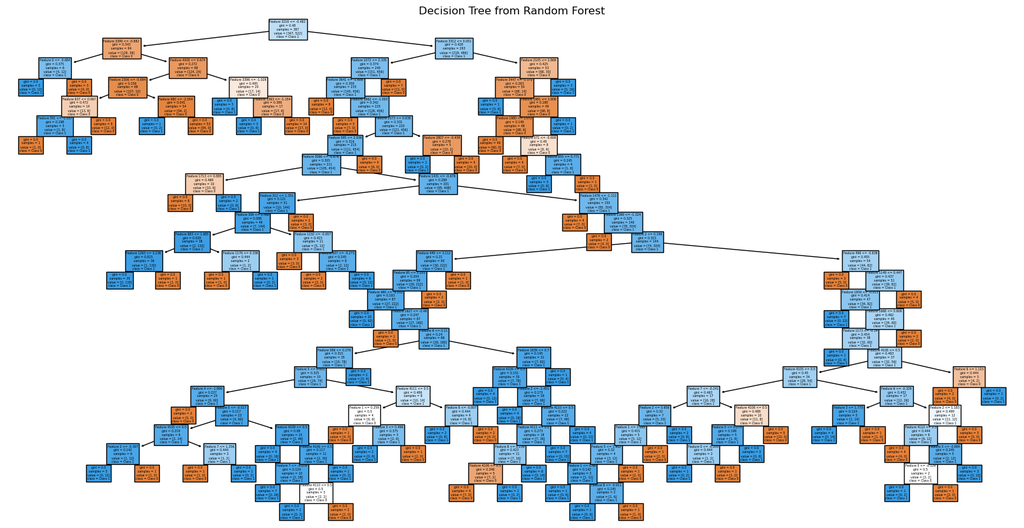

```python
tree = model_randomforest.estimators_[0]
# Visualize the tree
plt.figure(figsize=(20, 10))
plot_tree(tree, filled=True, feature_names=[f"Feature {i}" for i in range(X_tabular.shape[1])], class_names=["Class 0", "Class 1"])
plt.title("Decision Tree from Random Forest")
plt.show()
```

```python
# Calculate accuracy using sklearn's function
accuracy = accuracy_score(y_test, y_pred)
print(f"Accuracy: {accuracy:.2f}")
```

```
Accuracy: 0.75
```

# Logistic regression

The code starts by selecting categorical features and creating a training dataframe (`df_training`) that includes both these features and the target variable "Diagnosis." It then separates the features (`X`) and the target (`y`). The dataset is split into training and testing sets using `train_test_split`. A preprocessing pipeline is defined using `ColumnTransformer`, which handles missing values in the categorical features by imputing them with the most frequent value and encoding them using `OrdinalEncoder`. The pipeline also includes scaling of the features using `StandardScaler`. A logistic regression model is then integrated into a complete pipeline, which applies preprocessing, scaling, and classification in sequence. The model is trained on the training data, and predictions are made on the test data. The performance of the model is evaluated using the `classification_report`, and the model pipeline is saved using `pickle`. Finally, a confusion matrix is computed to assess the accuracy of the predictions, and it is visualized using a heatmap.

```python
categorical_features = ['Sex', 'BMI_Category','CRP_Category', 'WBC_Count_Category', 'Temperature_Category', 'Alvarado_Score_Category', 'Migratory_Pain', 'US_Performed', 'Ipsilateral_Rebound_Tenderness', 'Lower_Right_Abd_Pain', 'Coughing_Pain', 'Nausea']
df_training=df[categorical_features + ['Diagnosis']]
```

```python
X = df_training.drop(columns=['Diagnosis'])
y = df_training['Diagnosis']

# Split the data
X_train, X_test, y_train, y_test = train_test_split(X, y, test_size=0.2, random_state=42)

# Create a pipeline for preprocessing and the model
preprocessor_logistics = ColumnTransformer(
    transformers=[
        ('cat', Pipeline([
            ('imputer', SimpleImputer(strategy='most_frequent')),  # Fill missing categorical values with most frequent
            ('encoder', OrdinalEncoder())  # Encode categorical variables
        ]), categorical_features)
    ]
)

model_pipeline = Pipeline(steps=[
    ('preprocessor', preprocessor_logistics),
    ('scaler', StandardScaler()),
    ('classifier', LogisticRegression(random_state=42, max_iter=1000))
])

# Train the pipeline
model_pipeline.fit(X_train, y_train)

# Predict on the test data
y_pred = model_pipeline.predict(X_test)

# Print classification report
print(classification_report(y_test, y_pred))

# Save the pipeline using pickle
with open('model_pipeline.pkl', 'wb') as file:
    pickle.dump(model_pipeline, file)
```

```
                 precision    recall  f1-score   support

   appendicitis       0.78      0.81      0.79        95
no appendicitis       0.66      0.61      0.64        57

       accuracy                           0.74       152
      macro avg       0.72      0.71      0.72       152
   weighted avg       0.73      0.74      0.73       152
```

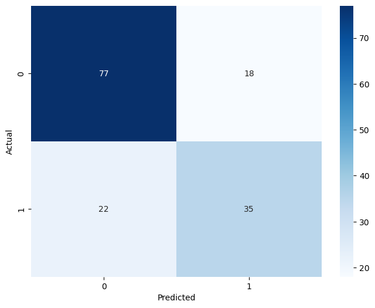

```python
#matplotlib.use("TkAgg")  # Or 'Qt5Agg', 'WXAgg', etc., depending on your system

# Confusion matrix
conf_matrix = confusion_matrix(y_test, y_pred)
plt.figure(figsize=(8, 6))
sns.heatmap(conf_matrix, annot=True, cmap='Blues', fmt='d')
plt.xlabel('Predicted')
plt.ylabel('Actual')
plt.show()
```

# SVC

The code begins by defining the target variable `y` as the "Diagnosis" column and splitting the dataset into training and testing sets using `train_test_split`. The features, `X_tabular`, which were preprocessed earlier, are used as the input for training. A Support Vector Machine (SVM) model (`SVC`) is then instantiated and trained on the training data. The trained model is used to predict the target on the test set. The model's performance is evaluated by printing the `classification_report`, which provides metrics like precision, recall, and F1 score. Additionally, a confusion matrix is computed to visually represent the performance of the model. The confusion matrix is displayed using a heatmap generated by `seaborn`, where the true and predicted values are compared for better insight into the model’s accuracy.

```python
from sklearn.svm import SVC
from sklearn.metrics import classification_report

y = df['Diagnosis']
X_train, X_test, y_train, y_test = train_test_split(X_tabular, y, test_size=0.2, random_state=42)
# Train the model using SVM
model_SVC = SVC(random_state=42)

# Fit the model on the training data
model_SVC.fit(X_train, y_train)

# Predict on the test data
y_pred = model_SVC.predict(X_test)

# Print classification report to evaluate the model
print(classification_report(y_test, y_pred))
```

```
                 precision    recall  f1-score   support

   appendicitis       0.80      0.79      0.79        95
no appendicitis       0.66      0.67      0.66        57

       accuracy                           0.74       152
      macro avg       0.73      0.73      0.73       152
   weighted avg       0.74      0.74      0.74       152
```

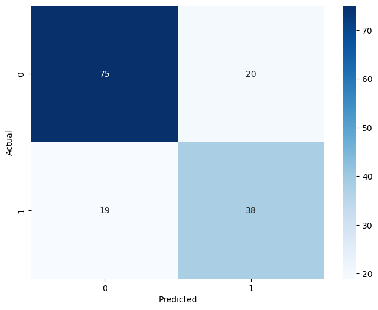

```python
#matplotlib.use("TkAgg")  # Or 'Qt5Agg', 'WXAgg', etc., depending on your system

# Confusion matrix
conf_matrix = confusion_matrix(y_test, y_pred)
plt.figure(figsize=(8, 6))
sns.heatmap(conf_matrix, annot=True, cmap='Blues', fmt='d')
plt.xlabel('Predicted')
plt.ylabel('Actual')
plt.show()
```